# Statistical Learning Final Project

廖偉傑、邱繼賢、邱婉如

```r
library(dplyr)
library(summarytools)
library(ggplot2)
library(GGally)
library(ggpubr)
library(corrplot)
library(psych)
```

# Data Preprocess

```r
mushroom_data = read.csv("secondary_data.csv", sep = ";")
# view(dfSummary(mushroom_data))
dim(mushroom_data)
```

```
## [1] 61069    21
```

```r
mushroom_data[mushroom_data==""] = NA
idx_factor_variable = c(1,3:9,12:21)
for (col in idx_factor_variable) {
    mushroom_data[,col] = as.factor(mushroom_data[,col])
}
# view(dfSummary(mushroom_data))
```

- 總共 61069 筆觀測值，21 個變數
- response variable : *class* (2 levels)
- 變數 *cap.diameter, stem.height, stem.width* 為連續型變數，其餘皆為類別型變數
- 變數 *cap.surface*(23.1%), *gill.attachment*(16.2%), *gill.spacing*(41.0%), *stem.root*(84.4%), *stem.surface*(62.4%), *veil.type*(94.8%), *veil.color*(87.9%), *ring.type*(4.0%), *spore.print.color*(89.6%) 有部分缺失值

```r
summary(mushroom_data$veil.type)
```

```
##     u  NA's
##  3177 57892
```

先移除變數 *veil.type*，因為此變數除了 NA 值只有 1 level，無法提供任何資訊

```r
mushroom_data = mushroom_data[,-15]
```

變數 *gill.spacing, stem.root, stem.surface, veil.color, spore.print.color* 缺失值比例也較高 (> 40%)，可以選擇刪除這些變數

```r
idx_remove = c(8,12,13,15,18)
mushroom_data = mushroom_data[,-idx_remove]
dim(mushroom_data)
```

```
## [1] 61069    15
```

剩餘 15 個變數  
(依舊有些變數具有 NA 值，先不處理，就看後續使用的模型能否對有 missing value 的資料分析，不行就 na.omit 掉)

```r
# Save cleaned data
write.csv(mushroom_data, "secondary_data_clean.csv", row.names = F)
```

變數 *ring.type* missing value 只有 4%，故直接移除其觀測值

```r
mushroom_data = mushroom_data[!is.na(mushroom_data$ring.type),]
dim(mushroom_data)
```

```
## [1] 58598    15
```

# EDA

```r
# ggpairs(mushroom_data)
```

## Response variable

- *class* : 2 levels nomial variable

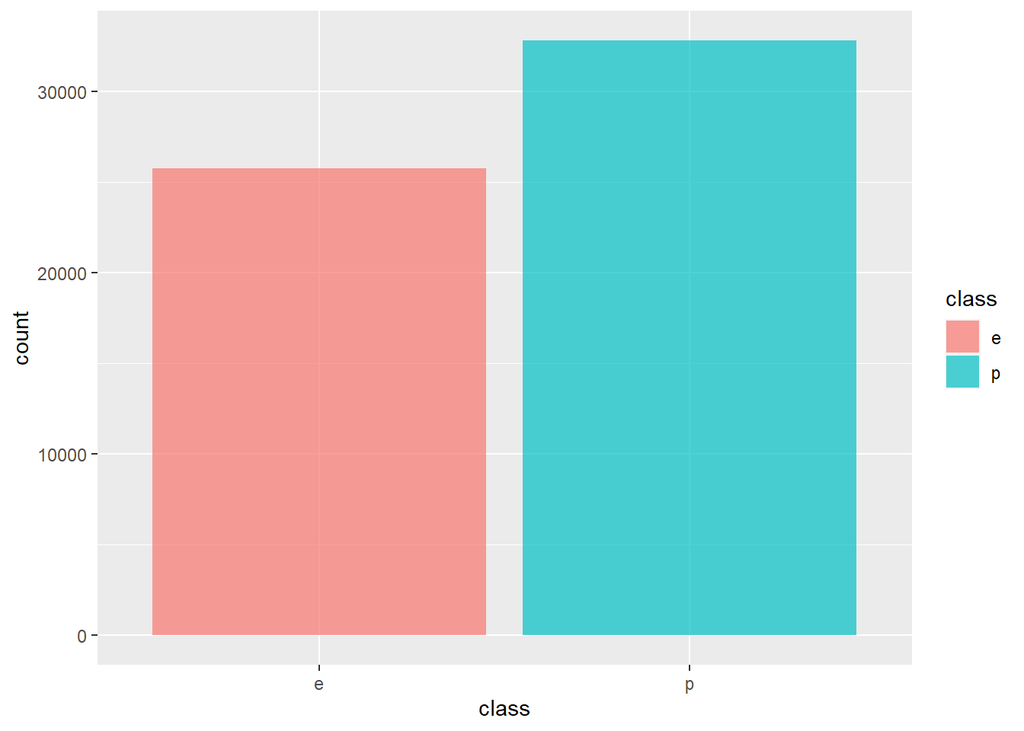

```r
prob_ = mean(mushroom_data$class=="p")
ggplot(mushroom_data) +
    geom_bar(aes(x = class, fill = class), alpha = 0.7)
```

有毒的蘑菇(*class*=p)在資料中總數略多(56.02%)，但差距不大，沒有 imbalance 現象

## Predictor vairables

### Continuous variables

- *cap.diameter* : 蘑菇傘蓋直徑(cm)
- *stem.height* : 蘑菇莖高度(cm)
- *stem.width* : 蘑菇莖寬度(mm)

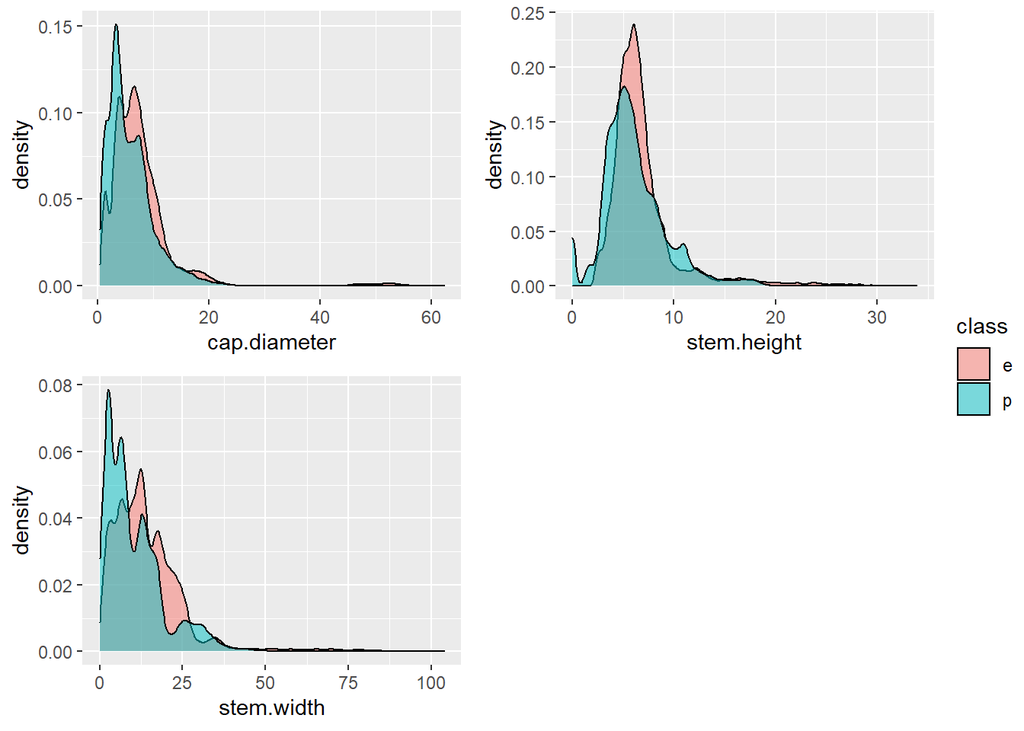

```r
p1 = ggplot(mushroom_data,
            aes(x = cap.diameter, fill = class)) +
    geom_density(alpha = 0.5)
p2 = ggplot(mushroom_data,
            aes(x = stem.height, fill = class)) +
    geom_density(alpha = 0.5)
p3 = ggplot(mushroom_data,
            aes(x = stem.width, fill = class)) +
    geom_density(alpha = 0.5)
ggarrange(p1,p2,p3, ncol = 2, nrow = 2,
          common.legend = T, legend = "right")
```

- 可食用的蘑菇 (*class*=e)，平均上來說蘑菇整體大小應該較大，但也不是很明顯

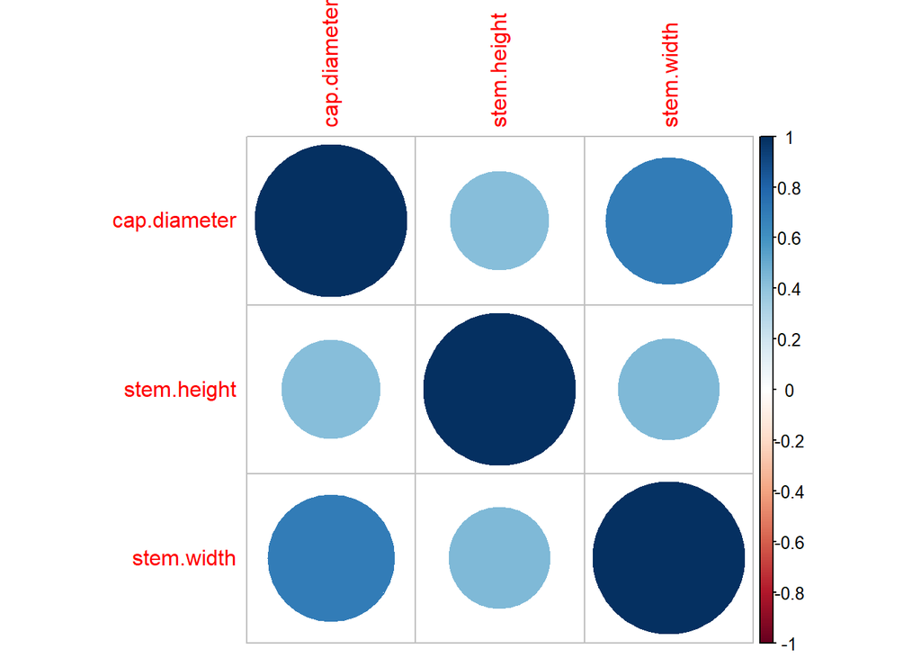

```r
cor_ = cor(mushroom_data[,c(2,9,10)])
corrplot(cor_)
```

- 三個連續型變數間皆是正相關，他們都可以反映蘑菇的大小
- *cap.diameter* 和 *stem.width* 之間有較強的正相關，推測是要有夠粗的莖才能撐住較大的傘頂，建模時可能會有共線性

### Catagorical variables

觀察各類別變數不同設定值下對 *class* 的數量及比例

#### 蘑菇傘蓋(cap)特徵：

- *cap.shape* : 蘑菇傘形狀 (7 levels)

| b | c | x | f | s | p | o |
| --- | --- | --- | --- | --- | --- | --- |
| 鐘型 (bell) | 圓錐形 (conical) | 凸型 (convex) | 平坦型 (flat) | 凹陷型 (sunken) | 球型 (spherical) | 其他 (other) |

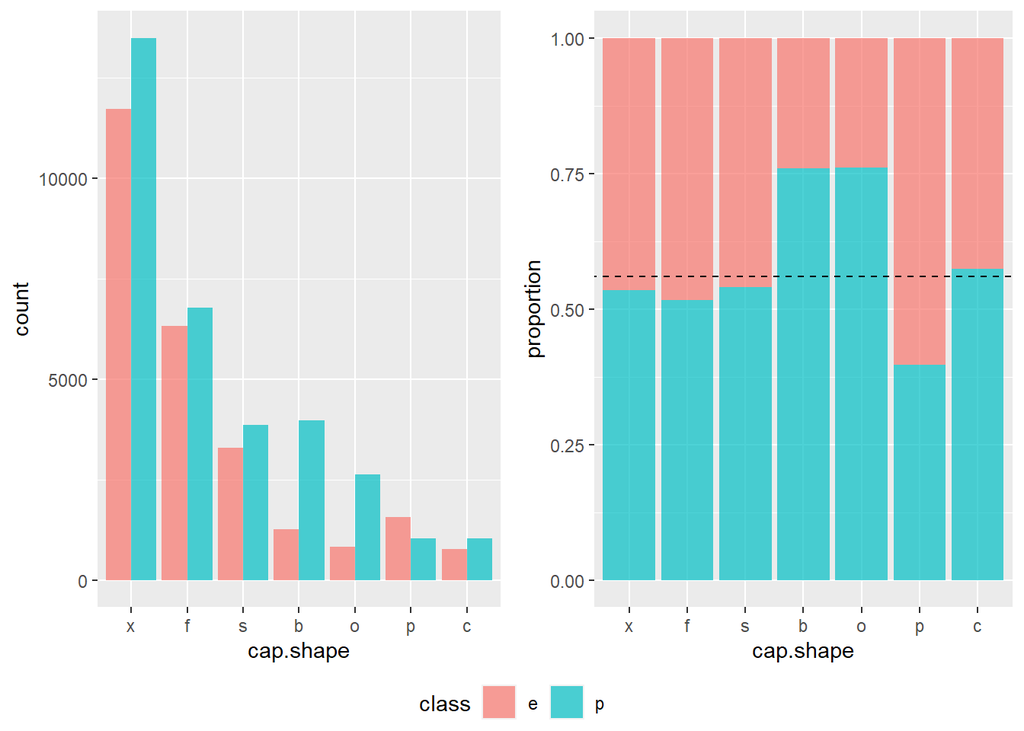

```r
# cap.shape
mushroom_data2 = mushroom_data %>%
    group_by(cap.shape, class) %>%
    summarise(count = n())

p1 = ggplot(mushroom_data2,
            aes(x = reorder(cap.shape,-count),
                y = count, fill = class)) +
    geom_bar(stat = "identity", position = "dodge",alpha = 0.7) +
    labs(x = "cap.shape")

p1.2 = ggplot(mushroom_data2,
            aes(x = reorder(cap.shape,-count), y = count,
                fill=class)) +
    geom_bar(stat = "identity",position = "fill", alpha = 0.7) +
    geom_abline(slope = 0, intercept = prob_, linetype = "dashed")+
    labs(x = "cap.shape", y="proportion")

ggarrange(p1,p1.2,ncol=2,nrow=1,
          common.legend = T, legend = "bottom")
```

- *cap.surface* : 蘑菇傘表面 (11 levels)

| i | g | y | s | h | l | k | t | w | e | d |
| --- | --- | --- | --- | --- | --- | --- | --- | --- | --- | --- |
| 纖維狀 (fibrous) | 凹槽 (grooves) | 鱗狀 (scaly) | 光滑 (smooth) | 閃亮 (shiny) | 革質 (leathery) | 絲質 (silky) | 黏性 (sticky) | 皺 (wrinkled) | 豐滿 (fleshy) |  |

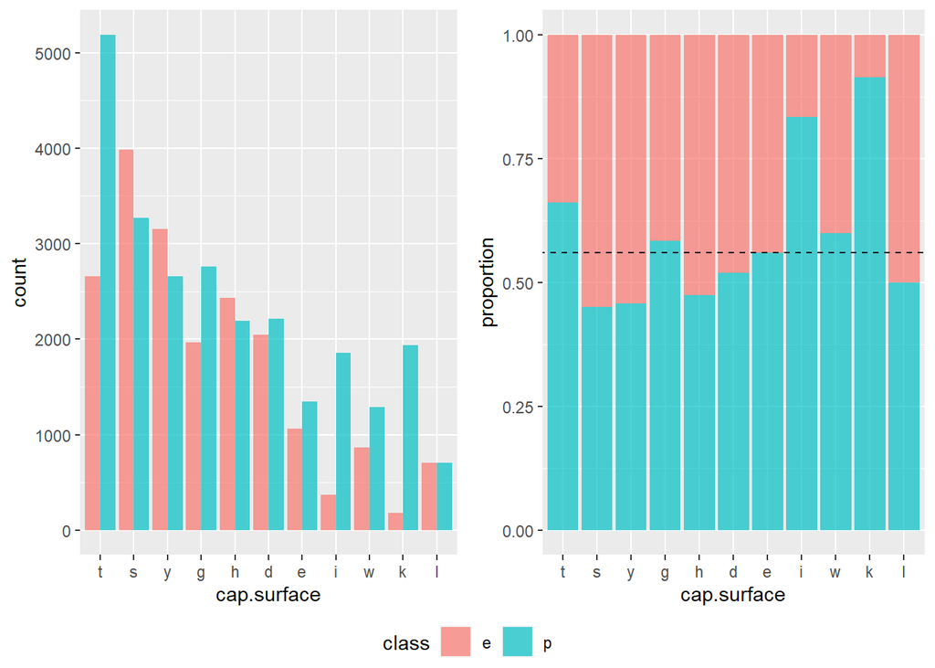

```r
# cap.surface
mushroom_data2 = mushroom_data %>%
    group_by(cap.surface, class) %>%
    summarise(count = n()) %>%
    na.omit()

p2 = ggplot(mushroom_data2,
            aes(x = reorder(cap.surface,-count),
                y = count, fill = class)) +
    geom_bar(stat = "identity", position = "dodge",alpha = 0.7) +
    labs(x = "cap.surface")

p2.2 = ggplot(mushroom_data2,
            aes(x = reorder(cap.surface,-count), y = count,
                fill=class)) +
    geom_bar(stat = "identity",position = "fill", alpha = 0.7) +
    geom_abline(slope = 0, intercept = prob_, linetype = "dashed")+
    labs(x = "cap.surface", y="proportion")

ggarrange(p2,p2.2,ncol=2,nrow=1,
          common.legend = T, legend = "bottom")
```

- *cap.color* : 蘑菇傘顏色 (12 levels)

| n | b | g | r | p | u | e | w | y | l | o | k |
| --- | --- | --- | --- | --- | --- | --- | --- | --- | --- | --- | --- |
| 棕色 (brown) | 淺黃色 (buff) | 灰色 (gray) | 綠色 (green) | 粉紅色 (pink) | 紫色 (purple) | 紅色 (red) | 白色 (white) | 黃色 (yellow) | 藍色 (blue) | 橘色 (orange) | 黑色 (black) |

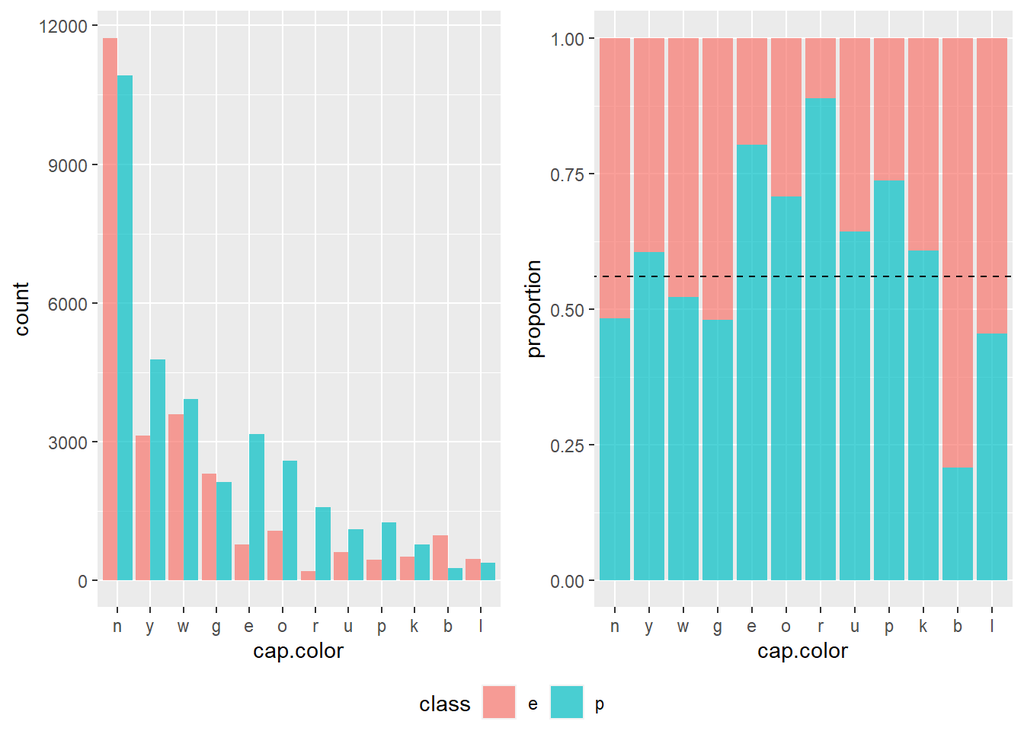

```r
# cap.color
mushroom_data2 = mushroom_data %>%
    group_by(cap.color, class) %>%
    summarise(count = n())

p3 = ggplot(mushroom_data2,
            aes(x = reorder(cap.color,-count),
                y = count, fill = class)) +
    geom_bar(stat = "identity", position = "dodge",alpha = 0.7) +
    labs(x = "cap.color")

p3.2 = ggplot(mushroom_data2,
            aes(x = reorder(cap.color,-count), y = count,
                fill=class)) +
    geom_bar(stat = "identity",position = "fill", alpha = 0.7) +
    geom_abline(slope = 0, intercept = prob_, linetype = "dashed")+
    labs(x = "cap.color", y="proportion")

ggarrange(p3,p3.2,ncol=2,nrow=1,
          common.legend = T, legend = "bottom")
```

- *does.bruise.or.bleed* : 是否有瘀傷或流血 (2 levels)

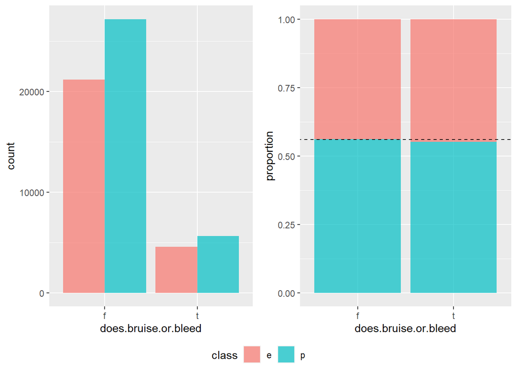

```r
# does.bruise.or.bleed
mushroom_data2 = mushroom_data %>%
    group_by(does.bruise.or.bleed, class) %>%
    summarise(count = n())

p4 = ggplot(mushroom_data2,
            aes(x = reorder(does.bruise.or.bleed,-count),
                y = count, fill = class)) +
    geom_bar(stat = "identity", position = "dodge",alpha = 0.7) +
    labs(x = "does.bruise.or.bleed")

p4.2 = ggplot(mushroom_data2,
            aes(x = reorder(does.bruise.or.bleed,-count), y = count,
                fill=class)) +
    geom_bar(stat = "identity",position = "fill", alpha = 0.7) +
    geom_abline(slope = 0, intercept = prob_, linetype = "dashed")+
    labs(x = "does.bruise.or.bleed", y="proportion")

ggarrange(p4,p4.2,ncol=2,nrow=1,
          common.legend = T, legend = "bottom")
```

#### 蘑菇菌褶(gill)特徵：

- *gill.attachment* : 菌褶附著物 (7 levels)

| a | x | d | e | s | p | f |
| --- | --- | --- | --- | --- | --- | --- |
| adnate | adnexed | decurrent | free | sinuate | pores | none |

See here : https://zh.m.wikipedia.org/zh-tw/%E8%8F%8C%E8%A4%B6

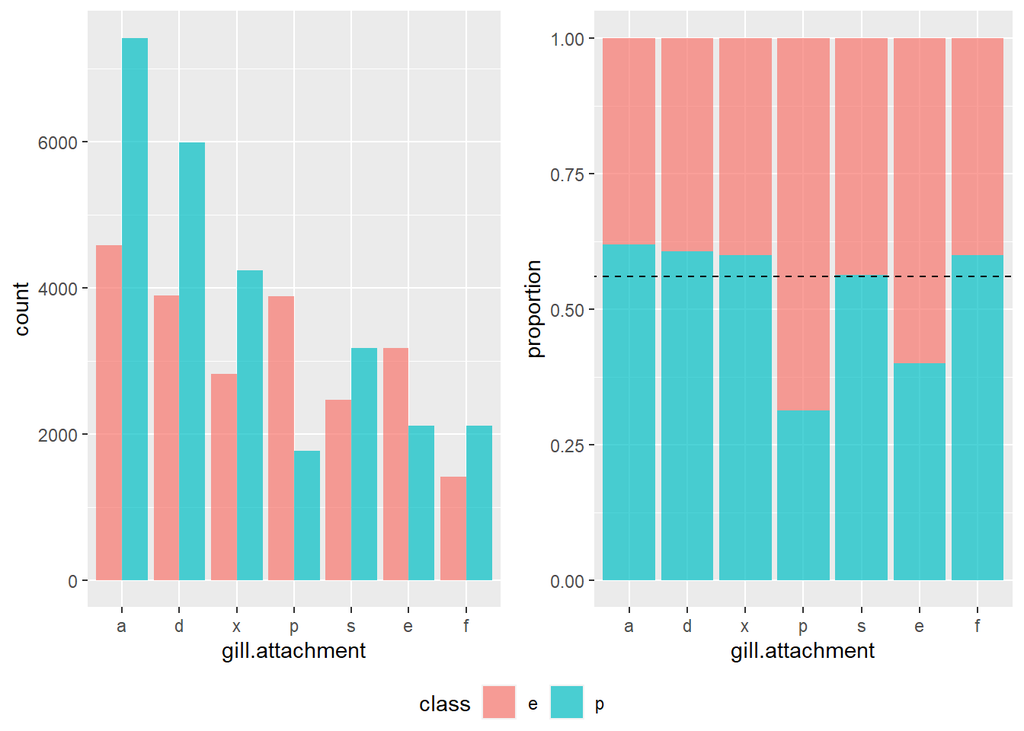

```r
# gill.attachment
mushroom_data2 = mushroom_data %>%
    group_by(gill.attachment, class) %>%
    summarise(count = n()) %>%
    na.omit()

p1 = ggplot(mushroom_data2,
            aes(x = reorder(gill.attachment,-count),
                y = count, fill = class)) +
    geom_bar(stat = "identity", position = "dodge",alpha = 0.7) +
    labs(x = "gill.attachment")

p1.2 = ggplot(mushroom_data2,
            aes(x = reorder(gill.attachment,-count), y = count,
                fill=class)) +
    geom_bar(stat = "identity",position = "fill", alpha = 0.7) +
    geom_abline(slope = 0, intercept = prob_, linetype = "dashed")+
    labs(x = "gill.attachment", y="proportion")

ggarrange(p1,p1.2,ncol=2,nrow=1,
          common.legend = T, legend = "bottom")
```

- *gill.color* : 菌褶顏色 (12 levels)

| n | b | g | r | p | u | e | w | y | l | o | k |
| --- | --- | --- | --- | --- | --- | --- | --- | --- | --- | --- | --- |
| 棕色 (brown) | 淺黃色 (buff) | 灰色 (gray) | 綠色 (green) | 粉紅色 (pink) | 紫色 (purple) | 紅色 (red) | 白色 (white) | 黃色 (yellow) | 藍色 (blue) | 橘色 (orange) | 黑色 (black) |

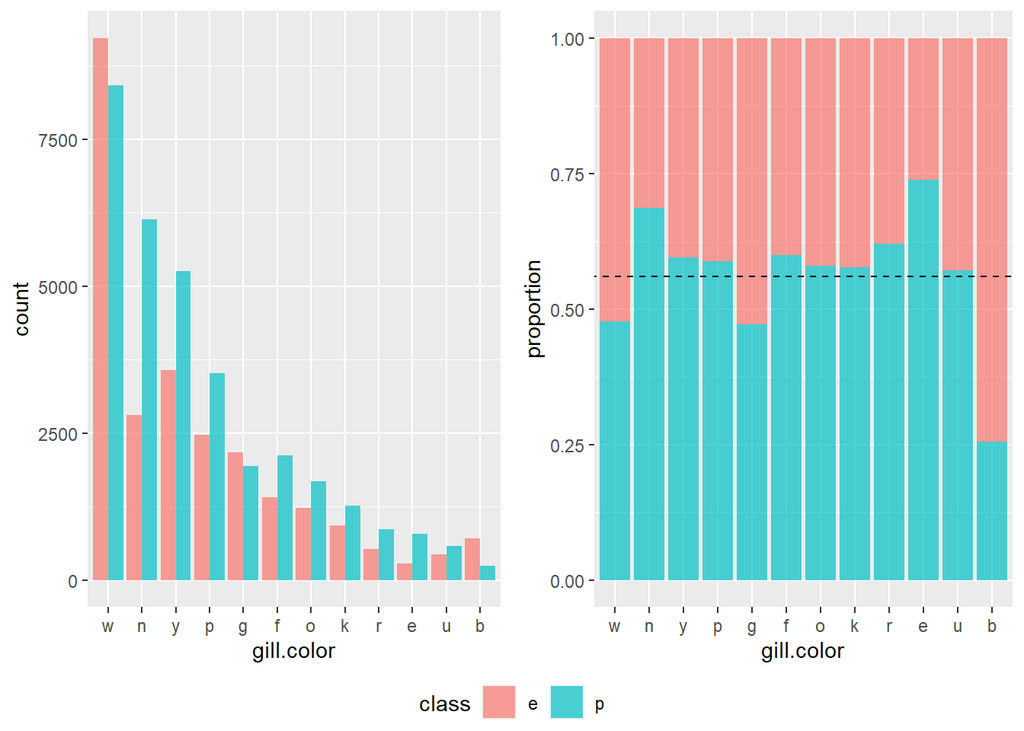

```r
# gill.color
mushroom_data2 = mushroom_data %>%
    group_by(gill.color, class) %>%
    summarise(count = n()) %>%
    na.omit()

p2 = ggplot(mushroom_data2,
            aes(x = reorder(gill.color,-count),
                y = count, fill = class)) +
    geom_bar(stat = "identity", position = "dodge",alpha = 0.7) +
    labs(x = "gill.color")

p2.2 = ggplot(mushroom_data2,
            aes(x = reorder(gill.color,-count), y = count,
                fill=class)) +
    geom_bar(stat = "identity",position = "fill", alpha = 0.7) +
    geom_abline(slope = 0, intercept = prob_, linetype = "dashed")+
    labs(x = "gill.color", y="proportion")

ggarrange(p2,p2.2,ncol=2,nrow=1,
          common.legend = T, legend = "bottom")
```

#### 蘑菇莖幹(stem)特徵：

- *stem.color* : 蘑菇莖顏色 (13 levels)

| n | b | g | r | p | u | e | w | y | l | o | k |
| --- | --- | --- | --- | --- | --- | --- | --- | --- | --- | --- | --- |
| 棕色 (brown) | 淺黃色 (buff) | 灰色 (gray) | 綠色 (green) | 粉紅色 (pink) | 紫色 (purple) | 紅色 (red) | 白色 (white) | 黃色 (yellow) | 藍色 (blue) | 橘色 (orange) | 黑色 (black) |

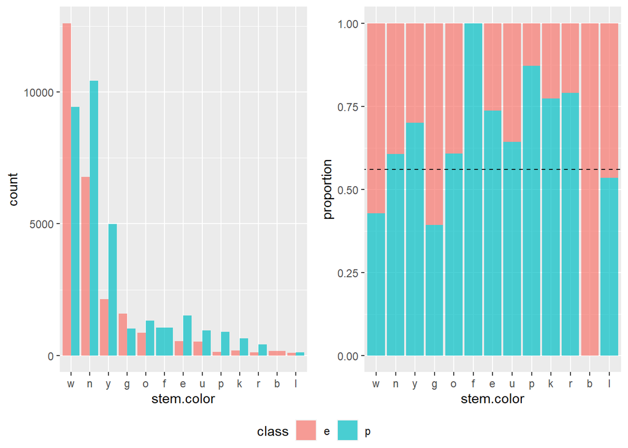

```r
mushroom_data2 = mushroom_data %>%
    group_by(stem.color, class) %>%
    summarise(count = n()) %>%
    na.omit()

p1 = ggplot(mushroom_data2,
            aes(x = reorder(stem.color,-count),
                y = count, fill = class)) +
    geom_bar(stat = "identity", position = "dodge",alpha = 0.7) +
    labs(x = "stem.color")

p1.2 = ggplot(mushroom_data2,
            aes(x = reorder(stem.color,-count), y = count,
                fill=class)) +
    geom_bar(stat = "identity",position = "fill", alpha = 0.7) +
    geom_abline(slope = 0, intercept = prob_, linetype = "dashed")+
    labs(x = "stem.color", y="proportion")

ggarrange(p1,p1.2,ncol=2,nrow=1,
          common.legend = T, legend = "bottom")
```

#### 蘑菇環(ring)特徵：

- *has.ring* : 蘑菇是否有環 (2 levels)

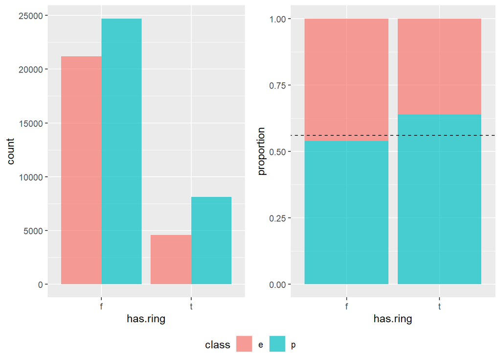

```r
# has.ring
mushroom_data2 = mushroom_data %>%
    group_by(has.ring, class) %>%
    summarise(count = n())

p1 = ggplot(mushroom_data2,
            aes(x = reorder(has.ring,-count),
                y = count, fill = class)) +
    geom_bar(stat = "identity", position = "dodge",alpha = 0.7) +
    labs(x = "has.ring")

p1.2 = ggplot(mushroom_data2,
            aes(x = reorder(has.ring,-count), y = count,
                fill=class)) +
    geom_bar(stat = "identity",position = "fill", alpha = 0.7) +
    geom_abline(slope = 0, intercept = prob_, linetype = "dashed")+
    labs(x = "has.ring", y="proportion")

ggarrange(p1,p1.2,ncol=2,nrow=1,
          common.legend = T, legend = "bottom")
```

- *ring.type* : 蘑菇環的種類 (8 levels)

| c | e | r | g | l | p | s | z | y | m | f |
| --- | --- | --- | --- | --- | --- | --- | --- | --- | --- | --- |
| 蛛網 (cobwebby) | 消逝 (evanescent) | 擴口 (flaring) | 凹槽 (grooved) | 大 (large) | 吊墜 (pendant) | 覆蓋物 (sheathing) | 環帶 (zone) | 鱗狀 (scaly) | 可移動 (movable) | 無 (none) |

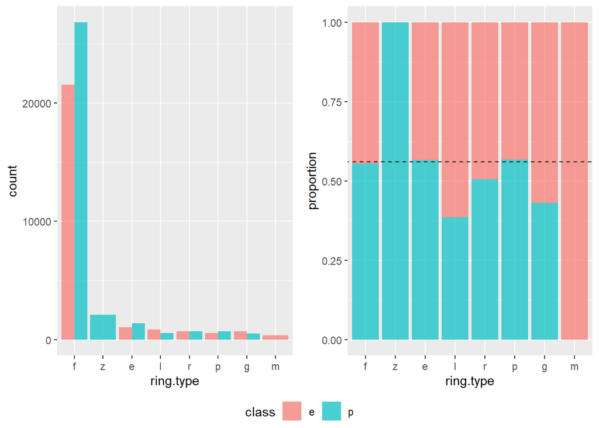

```r
# ring.type
mushroom_data2 = mushroom_data %>%
    group_by(ring.type, class) %>%
    summarise(count = n()) %>%
    na.omit()

p2 = ggplot(mushroom_data2,
            aes(x = reorder(ring.type,-count),
                y = count, fill = class)) +
    geom_bar(stat = "identity", position = "dodge",alpha = 0.7) +
    labs(x = "ring.type")

p2.2 = ggplot(mushroom_data2,
            aes(x = reorder(ring.type,-count), y = count,
                fill=class)) +
    geom_bar(stat = "identity",position = "fill", alpha = 0.7) +
    geom_abline(slope = 0, intercept = prob_, linetype = "dashed")+
    labs(x = "ring.type", y="proportion")

ggarrange(p2,p2.2,ncol=2,nrow=1,
          common.legend = T, legend = "bottom")
```

#### 蘑菇生長特徵：

- *habitat* : 蘑菇生長環境 (8 levels)

| g | l | m | p | h | u | w | d |
| --- | --- | --- | --- | --- | --- | --- | --- |
| 草 (grasses) | 樹葉 (leaves) | 草地 (meadows) | 道路 (paths) | 荒地 (heaths) | 城市 (urban) | 垃圾 (waste) | 樹林 (woods) |

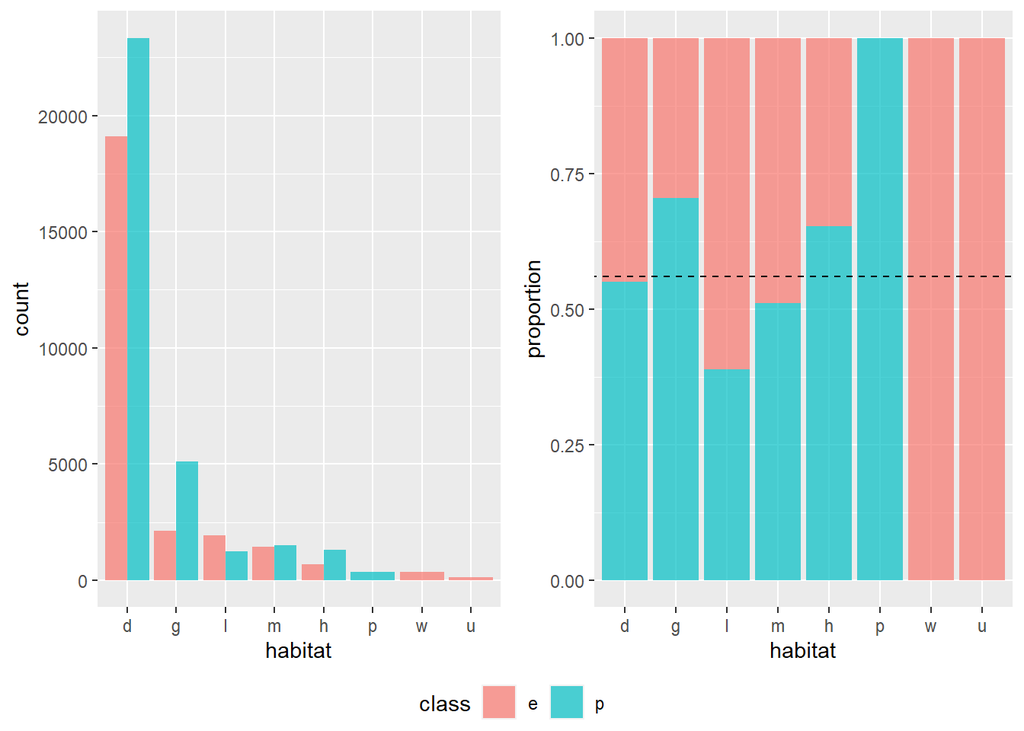

```r
# habitat
mushroom_data2 = mushroom_data %>%
    group_by(habitat, class) %>%
    summarise(count = n())

p1 = ggplot(mushroom_data2,
            aes(x = reorder(habitat,-count),
                y = count, fill = class)) +
    geom_bar(stat = "identity", position = "dodge",alpha = 0.7) +
    labs(x = "habitat")

p1.2 = ggplot(mushroom_data2,
            aes(x = reorder(habitat,-count), y = count,
                fill=class)) +
    geom_bar(stat = "identity",position = "fill", alpha = 0.7) +
    geom_abline(slope = 0, intercept = prob_, linetype = "dashed")+
    labs(x = "habitat", y="proportion")

ggarrange(p1,p1.2,ncol=2,nrow=1,
          common.legend = T, legend = "bottom")
```

- *season* : 蘑菇生長季節 (4 levels)

| s | u | a | w |
| --- | --- | --- | --- |
| 春天 (spring) | 夏天 (summer) | 秋天 (autumn) | 冬天 (winter) |

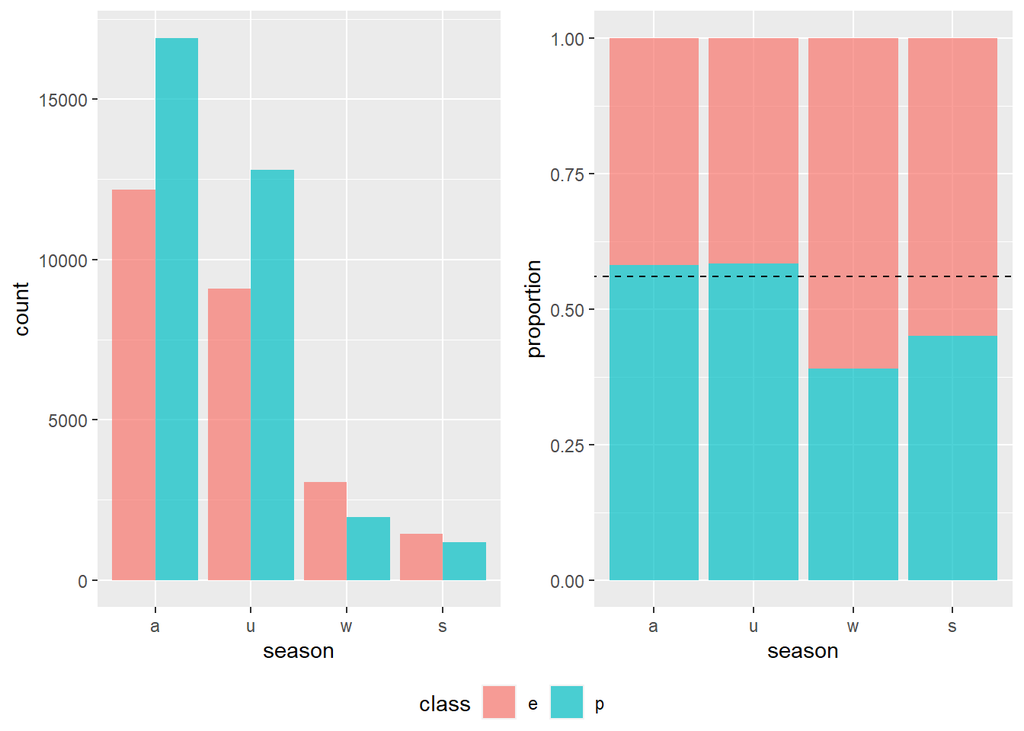

```r
# season
mushroom_data2 = mushroom_data %>%
    group_by(season, class) %>%
    summarise(count = n()) %>%
    na.omit()

p2 = ggplot(mushroom_data2,
            aes(x = reorder(season,-count),
                y = count, fill = class)) +
    geom_bar(stat = "identity", position = "dodge",alpha = 0.7) +
    labs(x = "season")

p2.2 = ggplot(mushroom_data2,
            aes(x = reorder(season,-count), y = count,
                fill=class)) +
    geom_bar(stat = "identity",position = "fill", alpha = 0.7) +
    geom_abline(slope = 0, intercept = prob_, linetype = "dashed")+
    labs(x = "season", y="proportion")

ggarrange(p2,p2.2,ncol=2,nrow=1,
          common.legend = T, legend = "bottom")
```

# Split train-test sets

## Missing value Imputation

對變數 *cap.surface* 和 *gill.attachment* 利用 multinomial logistic regression 進行補值

```r
library(nnet)
```

```r
set.seed(1221)
idx_train = sample(1:58598,46878)
mushroom_data_train = mushroom_data[idx_train,]
mushroom_data_test = mushroom_data[-idx_train,]
```

```r
mushroom_data = mushroom_data %>%
    mutate(cap.surface_impute = cap.surface)

mushroom_data$cap.surface_impute[idx_cap.surface_na] = pred_cap.surface
```

[output not shown]

[output not shown]

```r
idx_gill.attachment_na = is.na(mushroom_data$gill.attachment)
pred_gill.attachment = predict(model_gill.attachment,
                               newdata = mushroom_data[idx_gill.attachment_na,-c(1,4,16)],
                               type = "class")
```

[output not shown]

[output not shown]

```r
mushroom_data = mushroom_data %>%
    mutate(gill.attachment_impute = gill.attachment)
mushroom_data$gill.attachment_impute[idx_gill.attachment_na] = pred_gill.attachment
```

```r
mushroom_data_train = mushroom_data[idx_train,]
mushroom_data_test = mushroom_data[-idx_train,]
```

```r
write.csv(mushroom_data_train,"mushroom_train.csv", row.names = F)
write.csv(mushroom_data_test,"mushroom_test.csv", row.names = F)
```

觀察補值前後此兩變數的分布：

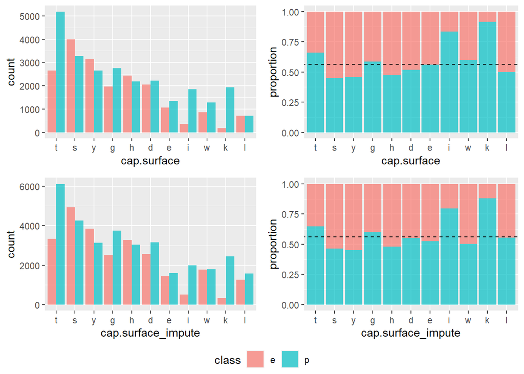

```r
# cap.surface
mushroom_data2 = mushroom_data %>%
    group_by(cap.surface, class) %>%
    summarise(count = n()) %>%
    na.omit() %>%
    ungroup()

p2 = ggplot(na.omit(mushroom_data2),
            aes(x = reorder(cap.surface,-count),
                y = count, fill = class)) +
    geom_bar(stat = "identity", position = "dodge",alpha = 0.7) +
    labs(x = "cap.surface")

p2.2 = ggplot(na.omit(mushroom_data2),
            aes(x = reorder(cap.surface,-count), y = count,
                fill=class)) +
    geom_bar(stat = "identity",position = "fill", alpha = 0.7) +
    geom_abline(slope = 0, intercept = prob_, linetype = "dashed")+
    labs(x = "cap.surface", y="proportion")


mushroom_data3 = mushroom_data %>%
    group_by(cap.surface_impute, class) %>%
    summarise(count = n()) %>%
    ungroup() %>%
    mutate(count2 = mushroom_data2$count)

p3 = ggplot(mushroom_data3,
            aes(x = reorder(cap.surface_impute,-count2),
                y = count, fill = class)) +
    geom_bar(stat = "identity", position = "dodge",alpha = 0.7) +
    labs(x = "cap.surface_impute")

p3.2 = ggplot(mushroom_data3,
            aes(x = reorder(cap.surface_impute,-count2), y = count,
                fill=class)) +
    geom_bar(stat = "identity",position = "fill", alpha = 0.7) +
    geom_abline(slope = 0, intercept = prob_, linetype = "dashed")+
    labs(x = "cap.surface_impute", y="proportion")

ggarrange(p2,p2.2,p3,p3.2,ncol=2,nrow=2,
          common.legend = T, legend = "bottom")
```

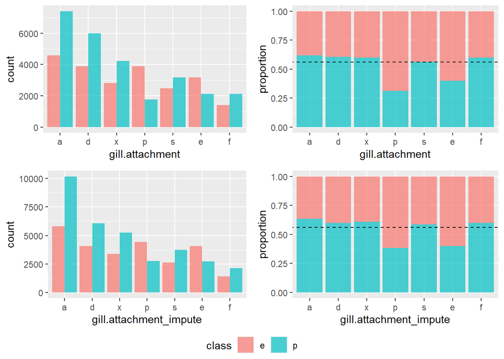

```r
# gill.attachment
mushroom_data2 = mushroom_data %>%
    group_by(gill.attachment, class) %>%
    summarise(count = n()) %>%
    na.omit() %>%
    ungroup()

p1 = ggplot(mushroom_data2,
            aes(x = reorder(gill.attachment,-count),
                y = count, fill = class)) +
    geom_bar(stat = "identity", position = "dodge",alpha = 0.7) +
    labs(x = "gill.attachment")

p1.2 = ggplot(mushroom_data2,
            aes(x = reorder(gill.attachment,-count), y = count,
                fill=class)) +
    geom_bar(stat = "identity",position = "fill", alpha = 0.7) +
    geom_abline(slope = 0, intercept = prob_, linetype = "dashed")+
    labs(x = "gill.attachment", y="proportion")


mushroom_data3 = mushroom_data %>%
    group_by(gill.attachment_impute, class) %>%
    summarise(count = n()) %>%
    ungroup() %>%
    mutate(count2 = mushroom_data2$count)


p3 = ggplot(mushroom_data3,
            aes(x = reorder(gill.attachment_impute,-count2),
                y = count, fill = class)) +
    geom_bar(stat = "identity", position = "dodge",alpha = 0.7) +
    labs(x = "gill.attachment_impute")

p3.2 = ggplot(mushroom_data3,
            aes(x = reorder(gill.attachment_impute,-count2), y = count,
                fill=class)) +
    geom_bar(stat = "identity",position = "fill", alpha = 0.7) +
    geom_abline(slope = 0, intercept = prob_, linetype = "dashed")+
    labs(x = "gill.attachment_impute", y="proportion")

ggarrange(p1,p1.2,p3,p3.2,ncol=2,nrow=2,
          common.legend = T, legend = "bottom")
```

```r
library(caret)
library(ROSE)
library(MASS)
library(e1071)
library(dplyr)
```

# 資料前處理

```r
dat6w_train = read.csv("mushroom_train.csv")[,-c(4,7,12)]
dat6w_test = read.csv("mushroom_test.csv")[,-c(4,7,12)]

dat6w_train$class = factor(dat6w_train$class)
dat6w_train$cap.shape = factor(dat6w_train$cap.shape)
dat6w_train$cap.surface_impute = factor(dat6w_train$cap.surface_impute)
dat6w_train$cap.color = factor(dat6w_train$cap.color)
dat6w_train$does.bruise.or.bleed = factor(dat6w_train$does.bruise.or.bleed)
dat6w_train$gill.attachment_impute = factor(dat6w_train$gill.attachment_impute)
dat6w_train$gill.color = factor(dat6w_train$gill.color)
dat6w_train$stem.color = factor(dat6w_train$stem.color)
dat6w_train$ring.type = factor(dat6w_train$ring.type)
dat6w_train$habitat = factor(dat6w_train$habitat)
dat6w_train$season = factor(dat6w_train$season)

dat6w_test$class = factor(dat6w_test$class)
dat6w_test$cap.shape = factor(dat6w_test$cap.shape)
dat6w_test$cap.surface_impute = factor(dat6w_test$cap.surface_impute)
dat6w_test$cap.color = factor(dat6w_test$cap.color)
dat6w_test$does.bruise.or.bleed = factor(dat6w_test$does.bruise.or.bleed)
dat6w_test$gill.attachment_impute = factor(dat6w_test$gill.attachment_impute)
dat6w_test$gill.color = factor(dat6w_test$gill.color)
dat6w_test$stem.color = factor(dat6w_test$stem.color)
dat6w_test$ring.type = factor(dat6w_test$ring.type)
dat6w_test$habitat = factor(dat6w_test$habitat)
dat6w_test$season = factor(dat6w_test$season)
```

# Logistic

```r
fit_lr_full = glm(class~., dat6w_train, family=binomial)
summary(fit_lr_full)
```

```
##
## Call:
## glm(formula = class ~ ., family = binomial, data = dat6w_train)
##
## Deviance Residuals:
##     Min       1Q   Median       3Q      Max
## -3.1751  -0.8136   0.0781   0.7906   2.8612
##
## Coefficients: (1 not defined because of singularities)
##                           Estimate Std. Error z value Pr(>|z|)
## (Intercept)             -15.769178 302.665158  -0.052 0.958448
## cap.diameter             -0.046766   0.004098 -11.412  < 2e-16 ***
## cap.shapec               -1.495923   0.089797 -16.659  < 2e-16 ***
## cap.shapef               -1.286673   0.056723 -22.683  < 2e-16 ***
## cap.shapeo                0.144157   0.102890   1.401 0.161190
## cap.shapep               -1.018346   0.077377 -13.161  < 2e-16 ***
## cap.shapes               -1.685466   0.068237 -24.700  < 2e-16 ***
## cap.shapex               -1.333143   0.053580 -24.881  < 2e-16 ***
## cap.colore                2.099711   0.115931  18.112  < 2e-16 ***
## cap.colorg                0.672649   0.113856   5.908 3.47e-09 ***
## cap.colork                1.405928   0.134312  10.468  < 2e-16 ***
## cap.colorl               -0.473430   0.146730  -3.227 0.001253 **
## cap.colorn                0.365500   0.105207   3.474 0.000513 ***
## cap.coloro                1.640203   0.116836  14.039  < 2e-16 ***
## cap.colorp                1.335643   0.132120  10.109  < 2e-16 ***
## cap.colorr                2.986873   0.139519  21.408  < 2e-16 ***
## cap.coloru                1.578106   0.127108  12.416  < 2e-16 ***
## cap.colorw                0.840861   0.110597   7.603 2.89e-14 ***
## cap.colory                0.788829   0.108792   7.251 4.14e-13 ***
## does.bruise.or.bleedt    -0.026430   0.038646  -0.684 0.494036
## gill.colore               1.416440   0.158955   8.911  < 2e-16 ***
## gill.colorf               0.280647   0.151025   1.858 0.063130 .
## gill.colorg               0.633361   0.129940   4.874 1.09e-06 ***
## gill.colork               0.591687   0.142209   4.161 3.17e-05 ***
## gill.colorn               0.919258   0.125375   7.332 2.27e-13 ***
## gill.coloro               0.666895   0.128106   5.206 1.93e-07 ***
## gill.colorp               0.318768   0.127622   2.498 0.012498 *
## gill.colorr               0.420758   0.148352   2.836 0.004565 **
## gill.coloru               1.228911   0.153224   8.020 1.05e-15 ***
## gill.colorw               0.576730   0.121701   4.739 2.15e-06 ***
```

[output cut: 43 more lines]

```
## gill.attachment_imputee  -0.722942   0.062025 -11.656  < 2e-16 ***
## gill.attachment_imputef         NA         NA      NA       NA
## gill.attachment_imputep  -2.227129   0.058606 -38.002  < 2e-16 ***
## gill.attachment_imputes  -0.096336   0.052954  -1.819 0.068875 .
## gill.attachment_imputex   0.235640   0.044390   5.308 1.11e-07 ***
## ---
## Signif. codes:  0 '***' 0.001 '**' 0.01 '*' 0.05 '.' 0.1 ' ' 1
##
## (Dispersion parameter for binomial family taken to be 1)
##
##     Null deviance: 64264  on 46877  degrees of freedom
## Residual deviance: 44144  on 46801  degrees of freedom
## AIC: 44298
##
## Number of Fisher Scoring iterations: 16
```

```r
glm.probs = predict(fit_lr_full, dat6w_test, type = "response")
glm.class = rep("e", length(glm.probs))
glm.class[glm.probs > 0.5] = "p"
confusionMatrix(factor(glm.class), dat6w_test$class, positive = "p") # ACC=0.7752
```

```
## Confusion Matrix and Statistics
##
##           Reference
## Prediction    e    p
##          e 3867 1266
##          p 1369 5218
##
##                Accuracy : 0.7752
##                  95% CI : (0.7675, 0.7827)
##     No Information Rate : 0.5532
##     P-Value [Acc > NIR] : < 2e-16
##
##                   Kappa : 0.5443
##
##  Mcnemar's Test P-Value : 0.04692
##
##             Sensitivity : 0.8048
##             Specificity : 0.7385
##          Pos Pred Value : 0.7922
##          Neg Pred Value : 0.7534
##              Prevalence : 0.5532
##          Detection Rate : 0.4452
##    Detection Prevalence : 0.5620
##       Balanced Accuracy : 0.7716
##
##        'Positive' Class : p
##
```

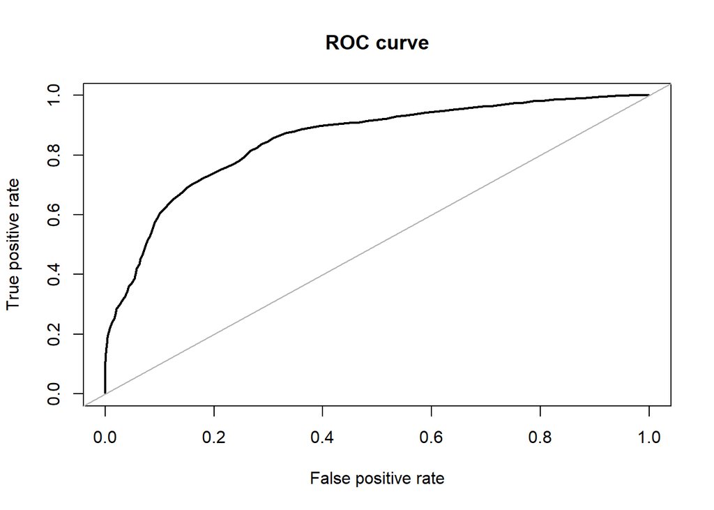

```
## Area under the curve (AUC): 0.850
```

```r
roc.curve(dat6w_test$class, glm.probs, plotit = T) # AUC=0.850
```

# LDA

```r
fit_lda = lda(class~., dat6w_train)
lda.pred = predict(fit_lda, dat6w_test)
lda.class = lda.pred$class
confusionMatrix(factor(lda.class), dat6w_test$class, positive = "p") # ACC=0.7702
```

```
## Confusion Matrix and Statistics
##
##           Reference
## Prediction    e    p
##          e 3908 1365
##          p 1328 5119
##
##                Accuracy : 0.7702
##                  95% CI : (0.7625, 0.7778)
##     No Information Rate : 0.5532
##     P-Value [Acc > NIR] : <2e-16
##
##                   Kappa : 0.5355
##
##  Mcnemar's Test P-Value : 0.4879
##
##             Sensitivity : 0.7895
##             Specificity : 0.7464
##          Pos Pred Value : 0.7940
##          Neg Pred Value : 0.7411
##              Prevalence : 0.5532
##          Detection Rate : 0.4368
##    Detection Prevalence : 0.5501
##       Balanced Accuracy : 0.7679
##
##        'Positive' Class : p
##
```

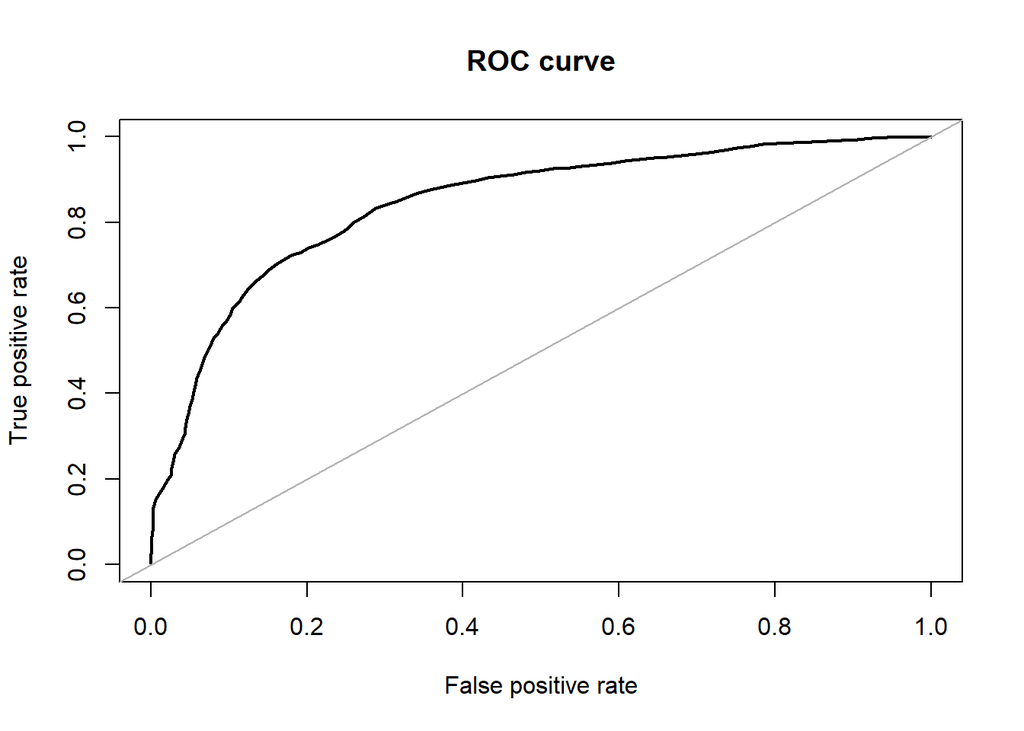

```
## Area under the curve (AUC): 0.845
```

```r
roc.curve(dat6w_test$class, lda.pred$posterior[,2], plotit = T) # AUC=0.845
```

# NB

```r
fit_nb = naiveBayes(class~., dat6w_train)
nb.class = predict(fit_nb, dat6w_test)
confusionMatrix(factor(nb.class), dat6w_test$class, positive = "p") # ACC=0.6632
```

```
## Confusion Matrix and Statistics
##
##           Reference
## Prediction    e    p
##          e 2533 1244
##          p 2703 5240
##
##                Accuracy : 0.6632
##                  95% CI : (0.6546, 0.6718)
##     No Information Rate : 0.5532
##     P-Value [Acc > NIR] : < 2.2e-16
##
##                   Kappa : 0.3
##
##  Mcnemar's Test P-Value : < 2.2e-16
##
##             Sensitivity : 0.8081
##             Specificity : 0.4838
##          Pos Pred Value : 0.6597
##          Neg Pred Value : 0.6706
##              Prevalence : 0.5532
##          Detection Rate : 0.4471
##    Detection Prevalence : 0.6777
##       Balanced Accuracy : 0.6460
##
##        'Positive' Class : p
##
```

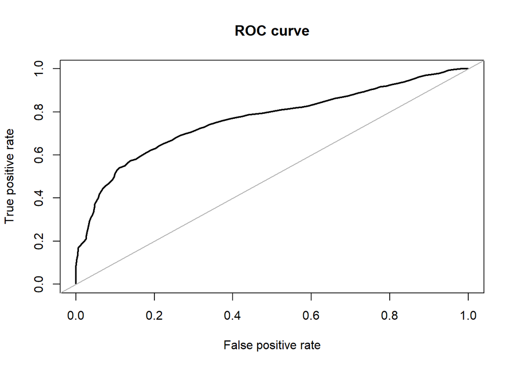

```
## Area under the curve (AUC): 0.765
```

```r
nb.probs = predict(fit_nb, dat6w_test, type="raw")
roc.curve(dat6w_test$class, nb.probs[,2], plotit = T) # AUC=0.765
```

# SVM

```r
fit_SVM = svm(class~., data=dat6w_train, kernel="radial", gamma=0.5, cost=10, probability=T)
pred_SVM = predict(fit_SVM, dat6w_test, probability=T)
prob_SVM = attr(pred_SVM,"probabilities")[,1]
pred_SVM = as.numeric(pred_SVM)-1
pred_SVM = ifelse(pred_SVM==1,"p","e")
confusionMatrix(factor(pred_SVM), dat6w_test$class, positive = "p") # ACC=0.9992
```

```
## Confusion Matrix and Statistics
##
##           Reference
## Prediction    e    p
##          e 5233    6
##          p    3 6478
##
##                Accuracy : 0.9992
##                  95% CI : (0.9985, 0.9996)
##     No Information Rate : 0.5532
##     P-Value [Acc > NIR] : <2e-16
##
##                   Kappa : 0.9984
##
##  Mcnemar's Test P-Value : 0.505
##
##             Sensitivity : 0.9991
##             Specificity : 0.9994
##          Pos Pred Value : 0.9995
##          Neg Pred Value : 0.9989
##              Prevalence : 0.5532
##          Detection Rate : 0.5527
##    Detection Prevalence : 0.5530
##       Balanced Accuracy : 0.9993
##
##        'Positive' Class : p
##
```

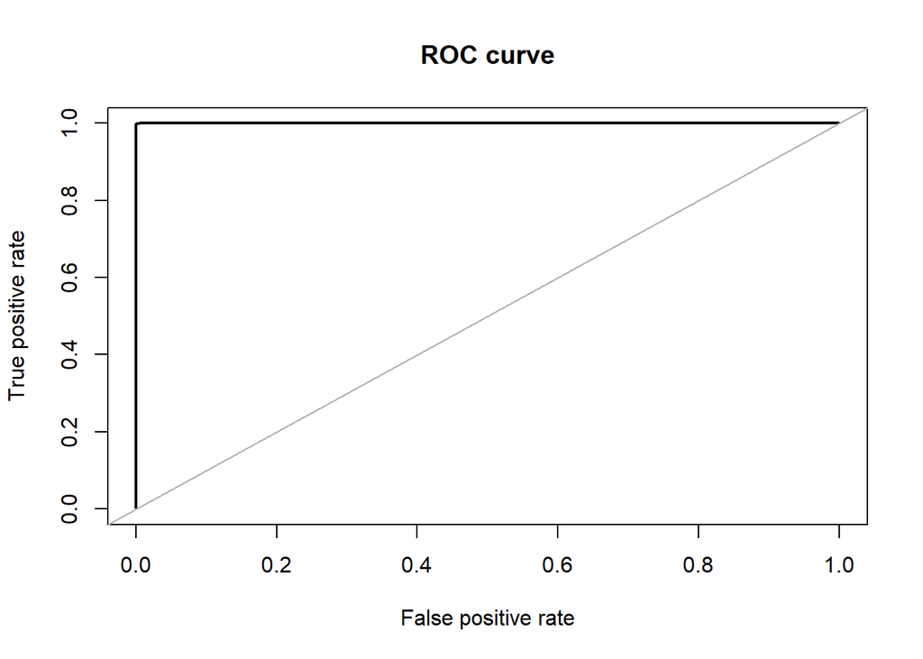

```
## Area under the curve (AUC): 1.000
```

```r
roc.curve(dat6w_test$class, prob_SVM, plotit = T) # AUC=1
```

# 毒鵝膏

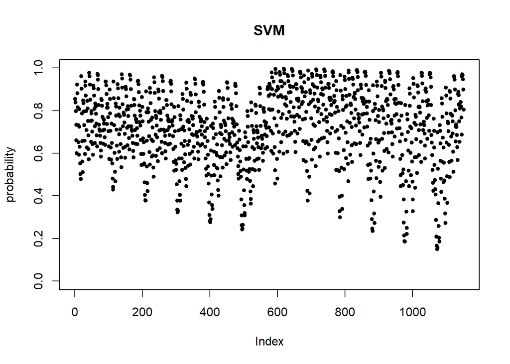

```r
library(designr)
pred.mush.na.l <- fixed.factor("cap.diameter", levels = seq(5,15,2)) +
  fixed.factor("cap.shape", levels =c("x","f")) +
  fixed.factor("cap.color", levels =c("r")) +
  fixed.factor("does.bruise.or.bleed", levels =c("t","f")) +
  fixed.factor("gill.color", levels =c("w")) +
  fixed.factor("stem.height", levels =seq(8,15,2)) +
  fixed.factor("stem.width", levels =seq(10,20,2)) +
  fixed.factor("stem.color", levels =c("w")) +
  fixed.factor("ring.type", levels =c("z")) +
  fixed.factor("habitat", levels =c("d")) +
  fixed.factor("season", levels =c("u","a")) +
  fixed.factor("cap.surface_impute", levels =c("t")) +
  fixed.factor("gill.attachment_impute", levels =c("e"))

fac.fn<-function(data,idx){
  for(i in idx){
    data[,i]<-as.factor(data[,i])
  }
  data.frame(data)
}

pred.mush.na<-data.frame(as.matrix(output.design(pred.mush.na.l)$codes))
pred.mush.na<-fac.fn(pred.mush.na,(1:13)[-c(1,6,7)])
pred.mush.na[,1]<-as.numeric(pred.mush.na[,1])
pred.mush.na[,6]<-as.numeric(pred.mush.na[,6])
pred.mush.na[,7]<-as.numeric(pred.mush.na[,7])
for(i in (1:13)[-c(1,6,7)]){
  levels(pred.mush.na[,i])<-levels(dat6w_train[,i+1])
}

pred_SVM2 = predict(fit_SVM, pred.mush.na, probability=T)
prob_SVM2 = attr(pred_SVM2,"probabilities")[,1]
pred_SVM2 = as.numeric(pred_SVM2)-1
pred_SVM2 = factor(ifelse(pred_SVM2==1,"p","e"))

par(mfrow=c(1,1))
plot(prob_SVM2,ylab="probability",main="SVM",pch=20,ylim=c(0,1))
```

```r
summary(pred_SVM2)
```

```
##    e    p
##  122 1030
```

# Model

## Decision tree (rpart)

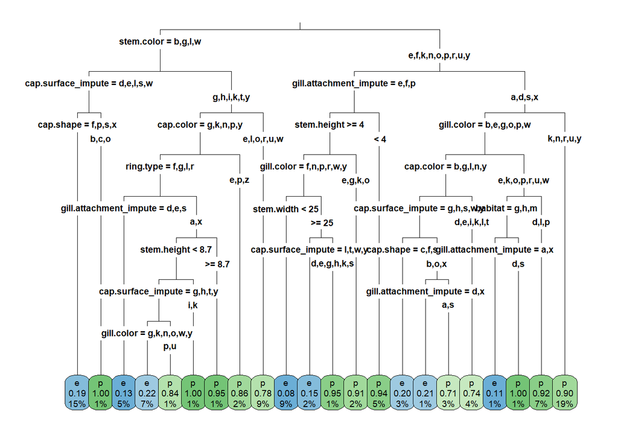

```r
mush.tree1.na<- rpart(class~ ., data=mush.train.na, method = 'class')
rpart.plot(mush.tree1.na, type = 3, fallen.leaves = T,cex=0.6)
```

```r
mush.tree1.prune.na <- prune(mush.tree1.na,
                          cp=mush.tree1.na$cptable[which.min(mush.tree1.na$cptable[,"xerror"]),"CP"])
# prp(mush.tree1.prune.na,fallen.leaves=TRUE, extra=1)
```

```r
mush.tree1.na.pred.test.p <- predict(mush.tree1.na, newdata=mush.test.na, type="prob")[,2]
mush.tree1.na.pred.test.c <- factor(ifelse(mush.tree1.na.pred.test.p>=0.5, 'p','e'))

mush.tree1.na.perform<-performance.fn(mush.tree1.na.pred.test.p,
                                      mush.tree1.na.pred.test.c, factor(mush.test.na$class),"Tree")
```

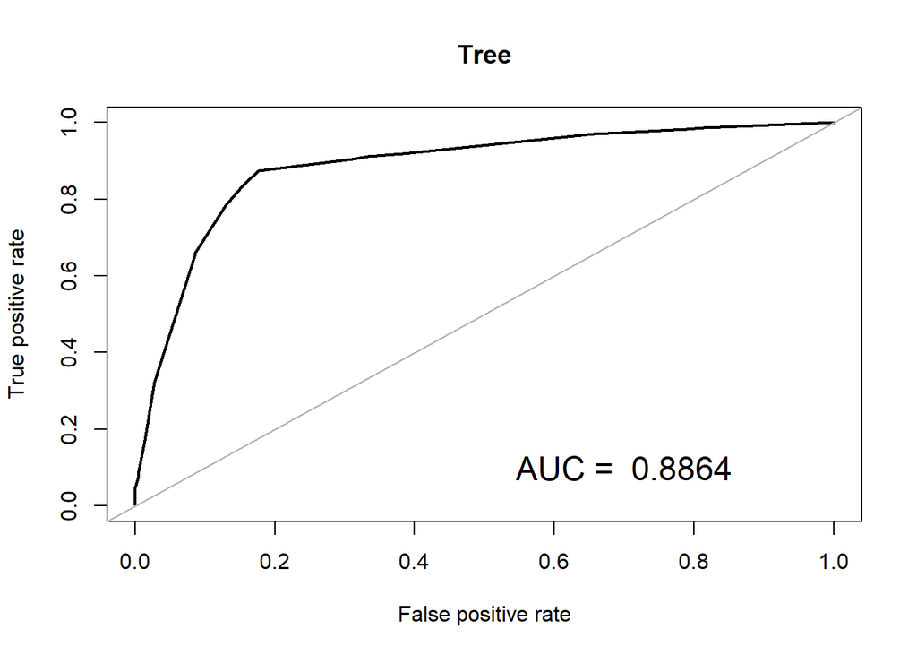

```
## Sensitivity Specificity         ACC
##       0.823       0.874       0.851
##           Reference
## Prediction    e    p
##          e 4311  818
##          p  925 5666
```

## Random forest

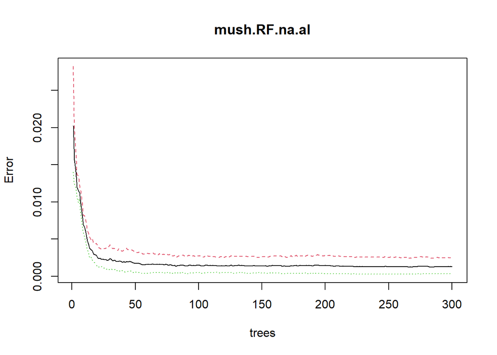

```r
mush.RF.na.al <- randomForest(class~., data=mush.train.na, ntree=300)
plot(mush.RF.na.al)
```

```r
set.seed(101)
tuneRF(mush.train.na[,-1],mush.train.na[,1], ntreeTry = 50)
```

```
## mtry = 3  OOB error = 0.15%
## Searching left ...
## mtry = 2     OOB error = 0.28%
## -0.7916667 0.05
## Searching right ...
## mtry = 6     OOB error = 0.13%
## 0.1666667 0.05
## mtry = 12    OOB error = 0.16%
## -0.25 0.05
```

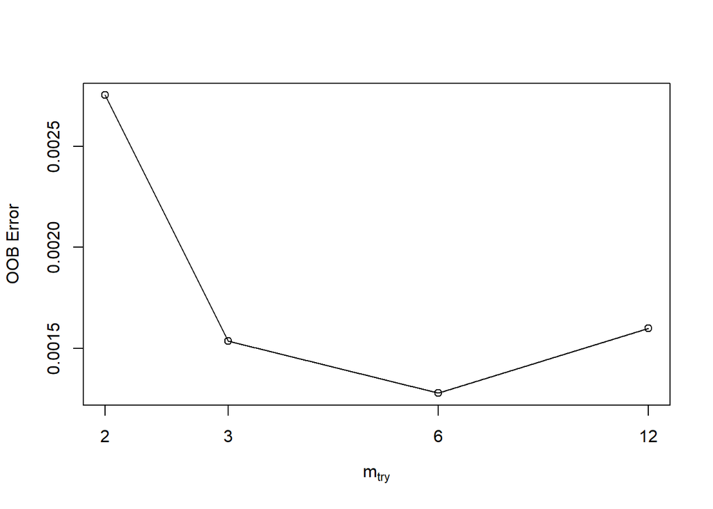

```
##        mtry    OOBError
## 2.OOB     2 0.002751824
## 3.OOB     3 0.001535902
## 6.OOB     6 0.001279918
## 12.OOB   12 0.001599898
```

```r
mush.RF.na <- randomForest(class~., data=mush.train.na,
                        mtry=6, ntree=50, importance=T)
```

```r
mush.RF.na.pred.test.p <- predict(mush.RF.na, mush.test.na, type='prob')[,2]
mush.RF.na.pred.test.c <- factor(ifelse(mush.RF.na.pred.test.p>=0.5, 'p','e'))

mush.RF.na.perform<-performance.fn(mush.RF.na.pred.test.p,
                                mush.RF.na.pred.test.c,
                                factor(mush.test.na$class),"Random Forest")
```

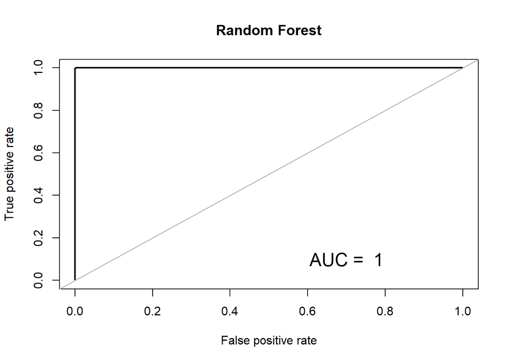

```
## Sensitivity Specificity         ACC
##       0.999       0.999       0.999
##           Reference
## Prediction    e    p
##          e 5232    6
##          p    4 6478
```

## Boosting

```r
# tune parameter
fitControl <- trainControl(method = "repeatedcv", number = 5, repeats = 5)
set.seed(101)
mush.boosting.na.tune <- train(class ~ ., data = mush.train.na, method = "gbm",
                    trControl = fitControl, verbose = FALSE)
mush.boosting.na.tune
```

```
## Stochastic Gradient Boosting
##
## 46878 samples
##    14 predictor
##     2 classes: 'e', 'p'
##
## No pre-processing
## Resampling: Cross-Validated (5 fold, repeated 5 times)
## Summary of sample sizes: 37502, 37503, 37503, 37502, 37502, 37503, ...
## Resampling results across tuning parameters:
##
##   interaction.depth  n.trees  Accuracy   Kappa
##   1                   50      0.6919493  0.3554059
##   1                  100      0.7343189  0.4538118
##   1                  150      0.7590725  0.5054515
##   2                   50      0.7649900  0.5188305
##   2                  100      0.8098596  0.6119394
##   2                  150      0.8374162  0.6690747
##   3                   50      0.8129868  0.6177773
##   3                  100      0.8661717  0.7272984
##   3                  150      0.8980118  0.7924970
##
## Tuning parameter 'shrinkage' was held constant at a value of 0.1
##
## Tuning parameter 'n.minobsinnode' was held constant at a value of 10
## Accuracy was used to select the optimal model using the largest value.
## The final values used for the model were n.trees = 150, interaction.depth =
##  3, shrinkage = 0.1 and n.minobsinnode = 10.
```

The final parameters used for the model were n.trees = 150, interaction.depth = 3, shrinkage = 0.1 and n.minobsinnode = 10.

```r
set.seed(101)
mush.train.boost.na <- mush.train.na
mush.test.boost.na <- mush.test.na
mush.train.boost.na$class <- as.numeric(mush.train.boost.na$class == "p")
mush.test.boost.na$class <- as.numeric(mush.test.boost.na$class == "p")

mush.boost.na <- gbm(class ~ ., data = mush.train.boost.na, distribution = "bernoulli",
                  n.trees = 150, interaction.depth = 3, shrinkage = 0.1, n.minobsinnode = 10)
mush.boost.na.sum<-data.frame(summary(mush.boost.na,plotit = F))
mush.boost.na.rel.inf<-mush.boost.na.sum$rel.inf
names(mush.boost.na.rel.inf)<-mush.boost.na.sum$var
```

```r
mush.boost.na.pred.test.p <- predict(mush.boost.na, data.frame(mush.test.boost.na), type = "response")
```

```
## Using 150 trees...
```

```r
mush.boost.na.pred.test.c <- factor(ifelse(mush.boost.na.pred.test.p>=0.5, 'p','e'))

mush.boost.na.perform<-performance.fn(mush.boost.na.pred.test.p,
                                   mush.boost.na.pred.test.c,
                                   factor(mush.test.na$class),"Boosting")
```

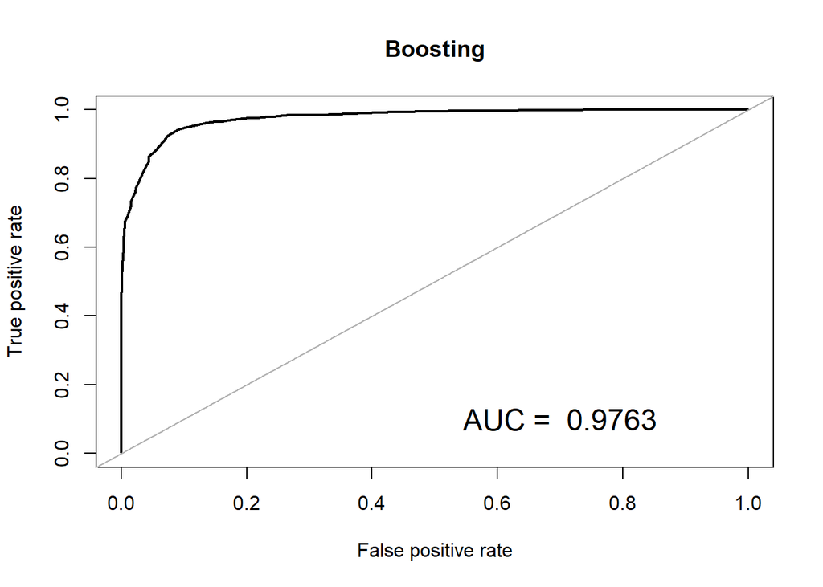

```
## Sensitivity Specificity         ACC
##       0.914       0.939       0.928
##           Reference
## Prediction    e    p
##          e 4787  396
##          p  449 6088
```

# Model performance comparison

```r
table.na <-(rbind(mush.tree1.na.perform$perform,
               mush.RF.na.perform$perform,
               rep(NA,3),
               mush.boost.na.perform$perform) %>% as.data.frame() %>%
  `colnames<-` (c('Sensitivity','Specificity','Accuracy'))%>%
  `rownames<-` (c('Decision tree','Random Forest','XGBoost','Boosting')))
kable(table.na,digits = 7)
```

|  | Sensitivity | Specificity | Accuracy |
| --- | --- | --- | --- |
| Decision tree | 0.8233384 | 0.8738433 | 0.8512799 |
| Random Forest | 0.9992361 | 0.9990746 | 0.9991468 |
| XGBoost | NA | NA | NA |
| Boosting | 0.9142475 | 0.9389266 | 0.9279010 |

# Variable Importance

## Relative variable Importance

```r
mush.tree.na.var.gg<-mush.tree1.prune.na$variable.importance %>%
as.matrix() %>%
as.data.frame() %>%
add_rownames() %>%
`colnames<-`(c("varname","Importance")) %>%
arrange(desc(Importance)) %>%
top_n(24,wt = Importance) %>%
ggplot(aes(x = reorder(varname, Importance),y = Importance)) +
geom_col(fill = 'orange', color = 'black') +
coord_flip() +
ggtitle(label = "Decision tree") +
xlab('Variable') +
ylab('Importance') +
theme(plot.title=element_text(hjust=0.5,size=15),
axis.title=element_text(size=15))
mush.RF.na.var.gg<-mush.RF.na$importance %>%
  as.matrix() %>%
  as.data.frame() %>%
  add_rownames() %>%
  `colnames<-`(c("varname",'No','Yes',"MeanDecreaseAccuracy",'MeanDecreaseGini')) %>%
  arrange(desc(MeanDecreaseAccuracy)) %>%
  top_n(24,wt = MeanDecreaseAccuracy) %>%
  ggplot(aes(x = reorder(varname, MeanDecreaseAccuracy),y = MeanDecreaseAccuracy)) +
  geom_col(fill = 'steelblue', color = 'black') +
  coord_flip() +
  ggtitle(label = "Random Forest") +
  xlab('Variable') +
  ylab('MeanDecreaseAccuracy') +
  theme(plot.title=element_text(hjust=0.5,size=15),
        axis.title=element_text(size=15))
```

```r
mush.boost.na.var.gg<-mush.boost.na.rel.inf %>%
  as.matrix() %>%
  as.data.frame() %>%
  add_rownames() %>%
  `colnames<-`(c("varname","Rel.Inf")) %>%
  arrange(desc(Rel.Inf)) %>%
  top_n(24,wt = Rel.Inf) %>%
  ggplot(aes(x = reorder(varname, Rel.Inf),y = Rel.Inf)) +
  geom_col(fill = 'green4', color = 'black') +
  coord_flip() +
  ggtitle(label = "Boosting") +
  xlab('Variable') +
  ylab('Relative Influence') +
  theme(plot.title=element_text(hjust=0.5,size=15),
        axis.title=element_text(size=15))
```

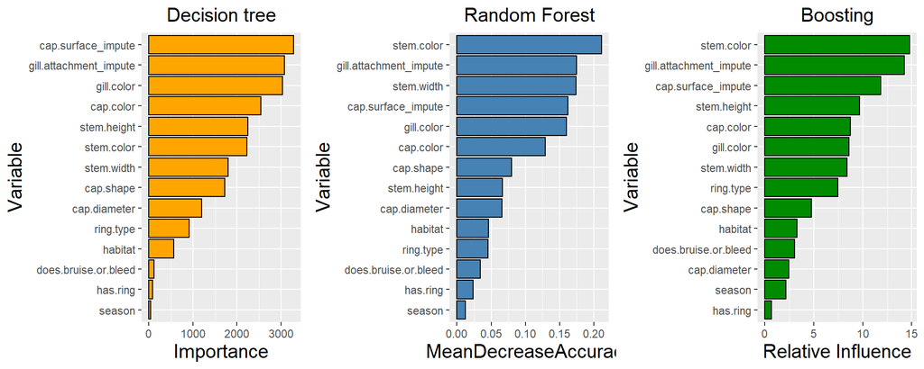

```r
ggarrange(mush.tree.na.var.gg,mush.RF.na.var.gg,mush.boost.na.var.gg,ncol=3,nrow=1)
```

## Partial dependence plot

### Random Forest

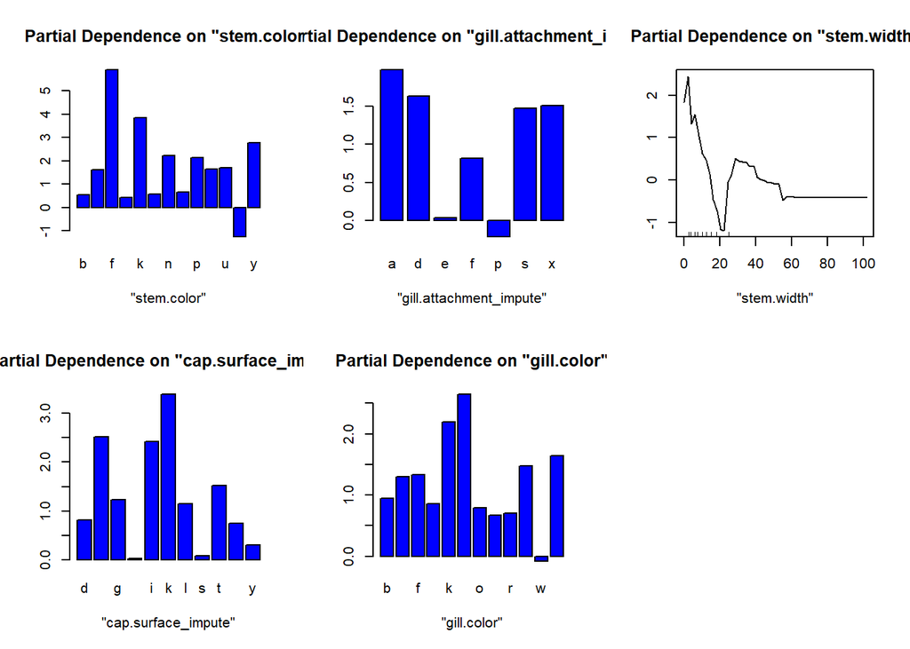

```r
par(mfrow=c(2,3))
partialPlot(mush.RF.na,pred.data = mush.train.na,x.var="stem.color", which.class="p")
partialPlot(mush.RF.na,pred.data = mush.train.na,x.var="gill.attachment_impute", which.class="p")
partialPlot(mush.RF.na,pred.data = mush.train.na,x.var="stem.width", which.class="p")
partialPlot(mush.RF.na,pred.data = mush.train.na,x.var="cap.surface_impute", which.class="p")
partialPlot(mush.RF.na,pred.data = mush.train.na,x.var="gill.color", which.class="p")
```